# LCA Star Supplementary Code

Niels W. Hanson, Kishori M. Konwar, Steven J. Hallam

Wednesday, June 1, 2016

# 1 Preample

- Load required R packages

```r
require(ggplot2)
require(reshape2)
require(dplyr)
```

- Set plotting theme

```r
theme_set(theme_bw())
```

# 2 Overview

Each simulation was run through the MetaPathways v2.0 pipeline [2], having its ORFs predicted and annotated against the RefSeq database using standard settings (Version 62, BSR=0.4, E-value=1e-5, Bit-score=20) [3]. Taxonomy for each ORF was annotated using the Lowest Common Ancestor (LCA) (or Best-BLAST in the GEBA SAGs), and overall contig taxonomy was predicted using three different methods: LCASquared, Simple Majority, and our information-theoretic LCAStar. LCASquared simply applies the LCA method again to the set of taxonomic ORF annotations on a contig. Simple Majority ascribes the taxonomy of the contig to the taxonomy that has the greatest number of annotations. The LCA* algorithm assigns taxonomy to contigs assembled from environmental sequence information using the NCBI Tree. The algorithm identifies a sufficiently strong majority on the hierarchy while minimizing entropy changes to the observed taxonomic distribution resulting in improved statistical properties. The default majority threshold is ($\alpha=0.51$).

We evaluated the performance of these predictions using two taxonomic distances on the NCBI taxonomic database hierarchy (NCBI Tree) [4]. The first is a Simple Walk of the the NCBI Tree from the observed predicted taxonomy to the original expected taxonomy. The second is a weighted taxonomic distance (WTD) that weightes each edge proportional to $\frac{1}{d}$ where $d$ is the depth of the edge in the tree (see [5, 6]) for more details. The NCBI Tree was slightly modified with the addition of a *prokaryotes* node as a parent of *Bacteria* and *Archaea* nodes.

## 2.1 Materials and Downloads

The most recent code is available on the [GitHub repository](https://github.com/hallamlab/lcastar). Data required for this analysis can be found: [lca_star_data.zip](https://www.dropbox.com/s/ew5v55eroa332mu/lca_star_data.zip?dl=0)

# 3 Simulations

## 3.1 Obtaining NCBI Genomes

- Downloaded `all.fna.tar.gz` and `summary.txt` from the NCBI’s ftp server: ftp://ftp.ncbi.nlm.nih.gov/genomes/ Mar 12, 2014
- The file `summary.txt` contains some metadata for a number of these genomes:

```
Accession  GenbankAcc  Length   Taxid   ProjectID   TaxName Replicon    Create Date Update_Date
NC_000907.1 L42023.1    1830138 71421   57771   Haemophilus influenzae Rd KW20  chromosome  Oct 19 2001 Sep 11 2013  4:30:20:076PM
```

- Extract NCBI IDs

```
cat summary.txt  | awk '{print $1}' > u
for s in `cat u`; do var1=`find . -name *${s%.[0-9]}*`; echo $s$'\t'$var1 >> ncbiID_to_file; done
```

- `summary.txt` is a fairly comprehensive list, but 25 genomes were dropped because they were not found in the `summary.txt` metadata file

```
grep --perl-regexp "\t$" ncbiID_to_file | wc
      25      25     324
grep --perl-regexp "\t$" ncbiID_to_file | wc
NC_003911.11
AC_000091.1
NC_009353.1
NC_009444.1
NC_010332.1
NS_000190.1
NC_011980.1
NS_000196.1
NS_000197.2
NC_012627.1
NC_012629.1
NC_012630.1
NC_012915.1
NC_013416.1
NC_013438.1
NC_013597.1
NC_013784.1
NC_013785.1
NC_013786.1
NC_013787.1
NC_013788.1
NC_014629.1
NC_015557.1
NC_015587.1
```

- This leaves a total of 2617 genomes in `ncbiID_to_file.txt`, which maps the NCBI IDs to the .fna file location

```
grep --perl-regexp ".*fna" ncbiID_to_file | wc
    2617    5234  197129
wc ncbiID_to_file
    2642    5259  197453 ncbiID_to_file
grep --perl-regexp ".*fna" ncbiID_to_file > ncbiID_to_file.txt
```

## 3.2 Simulation

The script subsample_ncbi.py was used to quickly sample from the collection of fasta files specified in our `ncbiID_to_file.txt`. This script creates the `test1` or Small and the `test2` or Large simulated metagenomes.

### 3.2.1 Small simulation

Here we create the `test1` (or Small simulation as it is referred to in the text). This script creates sub-sequences of length 10,000, sampling 10 sequences per file on a random subset of 100 (the random number generator is seeded so that results can be reproducible)

```
python subsample_ncbi.py -i ncbiID_to_file.txt -l 10000 -s 10 -n 100 -o lca_star_test1.fasta
```

Creating our Small simulated contigs file: `lca_star_test1.fasta`

### 3.2.2 Large simulation

For a second test we sampled sequences of length 10,000 using 10 subsamples from 2,000 randomly selected genomes. Here, we repeated the Small procedure except with significantly more input sequences.

```
python subsample_ncbi.py -i ncbiID_to_file.txt -o lca_test2.fasta -l 10000 -s 10 -n 2000
```

# 4 GEBA SAGs

The 201 Single-cell amplified genome (SAG) microbial ‘dark matter’ assembies were obtained from https://img.jgi.doe.gov under the Study Name `GEBA-MDM` [7]. Combined assemblies were excluded from this analysis.

# 5 MetaPathways Annotation

## 5.1 With Targets

The Small, Large, and 201 MDM SAG assemblies were annotated against RefSeq v62 via MetaPathways v2.0 pipeline [2] using standard quality control settings and the LAST homology-search algorithm [8].

## 5.2 Without Targets

As a secondary experiment to determine the capacity of LCA* to assign taxonomy with no reference sequences, the Small and Large simulations were annotated against RefSeq v62, but with all genes of originating organisms used in the Small and Large simulations removed.

# 6 Running LCAStar

The script run_lca_star_analysis.sh runs the Small, Larger, and MDM SAG contigs through the pipeline

The outputs of these runs can be found in [lca_star_data.zip](https://www.dropbox.com/s/ew5v55eroa332mu/lca_star_data.zip?dl=0):

- `test1_lcastar.txt`: LCAStar output for the Small simulation
- `test2_lcastar.txt`: LCAStar output for the Large simulation
- `test1_removed_lcastar.txt`: LCAStar output for the Small simulation with target genomes removed from RefSeq
- `test2_removed_lcastar.txt`: LCAStar output for the Large simulation with target genomes removed from RefSeq
- `GEBA_SAG_all_lcastar.txt`: LCAStar output for the 201 GEBA SAGs

# 7 Analysis of LCAStar Results

- Read and merge the datasets

```r
colClasses <- c("character", "character", "numeric", "numeric", "numeric",
                "character", "numeric", "numeric", "numeric",
                "character", "numeric", "numeric", "character" )
test1_df <- read.table("lca_star_results/test1_lcastar.txt",
                       sep="\t",
                       header=T,
                       na.strings = "None",
                       colClasses = colClasses,
                       strip.white=TRUE,
                       quote="")
test2_df <- read.table("lca_star_results/test2_lcastar.txt",
                       sep="\t",
                       header=T,
                       na.strings = "None",
                       colClasses = colClasses,
                       strip.white=TRUE,
                       quote="")
test1_removed_df <- read.table("lca_star_results/test1_removed_03-04-2016_lcastar.txt",
                               sep="\t",
                               header=T,
                               na.strings = "None",
                               colClasses = colClasses,
                               strip.white=TRUE,
                               quote="")
test2_removed_df <- read.table("lca_star_results/test2_removed_03-04-2016_lcastar.txt",
                               sep="\t",
                               header=T,
                               na.strings = "None",
                               colClasses = colClasses,
                               strip.white=TRUE,
                               quote="")
geba_df <- read.table("lca_star_results/GEBA_SAG_all_lcastar.txt",
                      sep="\t",
                      header=T,
                      na.strings = "None",
                      colClasses = colClasses,
                      strip.white=TRUE,
                      quote="")

all_df <- rbind(cbind(geba_df, Sample="GEBA MDM"),
                cbind(test1_df, Sample="Small"),
                cbind(test2_df, Sample="Large"),
                cbind(test1_removed_df, Sample="Small (Removed)"),
                cbind(test2_removed_df, Sample="Large (Removed)")
                )

all_df$Sample <- factor(all_df$Sample,
                        levels=c("Small", "Large", "Small (Removed)", "Large (Removed)", "GEBA MDM")
                        )
```

- Compare p-value calculations between the Majority and LCA* methods

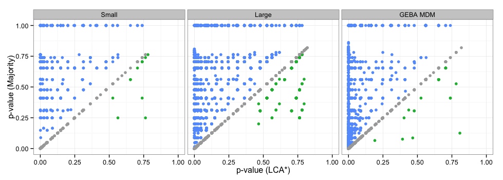

```r
# p-value compare
dat <- all_df %>% subset(Sample %in% c("Small", "Large", "GEBA MDM"))
g1 <- ggplot(dat, aes(x=LCAStar_p, y=Majority_p))
g1 <- g1 + geom_point(data = subset(dat, LCAStar_p > Majority_p), color="#1BB840")
g1 <- g1 + geom_point(data = subset(dat, LCAStar_p < Majority_p), color="#649EFC")
g1 <- g1 + geom_point(data = subset(dat, LCAStar_p == Majority_p), color="darkgrey")
g1 <- g1 + xlim(0,1)
g1 <- g1 + ylim(0,1)
g1 <- g1 + xlab("p-value (LCA*)")
g1 <- g1 + ylab("p-value (Majority)")
g1 <- g1 + facet_wrap(~ Sample)
g1 <- g1 + theme(legend.position="none")
g1
```

```r
pdf(file = "pdfs/fig1.pdf", width = 10.2, height=3.65)
g1
dev.off()
```

**Figure 1:** Comparing p-values of taxonomic voting statistics Majority and LCA*.

Notes:

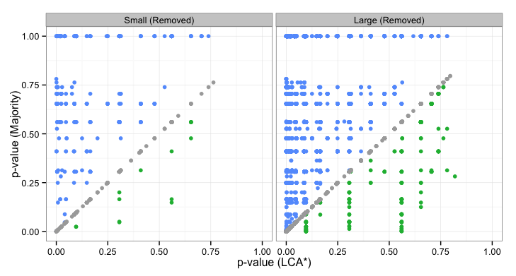

```r
dat <- all_df %>% subset(Sample %in% c("Small (Removed)", "Large (Removed)"))

g1a <- ggplot(dat, aes(x=LCAStar_p, y=Majority_p))
g1a <- g1a + geom_point(data = subset(dat, LCAStar_p > Majority_p), color="#1BB840")
g1a <- g1a + geom_point(data = subset(dat, LCAStar_p < Majority_p), color="#649EFC")
g1a <- g1a + geom_point(data = subset(dat, LCAStar_p == Majority_p), color="darkgrey")
g1a <- g1a + xlim(0,1)
g1a <- g1a + ylim(0,1)
g1a <- g1a + xlab("p-value (LCA*)")
g1a <- g1a + ylab("p-value (Majority)")
g1a <- g1a + facet_wrap(~ Sample)
g1a <- g1a + theme(legend.position="none")
g1a
```

```r
pdf(file = "pdfs/fig1a.pdf", width = 7.595238, height=4.078740)
g1a
dev.off()
```

**Figure 1a:** Comparing p-values of taxonomic voting statistics Majority and LCA* from the Small and Large simulations (targets removed).

Notes: * p-value pattern very simmilar to before, however there are more examples in the large sample of p-values where the simple majority has the smaller p-value.

Function to format and reshape data for ggplot:

```r
clean_up_data2 <- function(df) {
  new_df <-rbind(cbind(df$Contig, df$LCAStar, "LCAStar", df$Original, df$LCAStar_p, df$LCAStar_dist, df$LCAStar_WTD),
           cbind(df$Contig, df$Majority, "Majority", df$Original, df$Majority_p, df$Majority_dist, df$Majority_WTD),
           cbind(df$Contig, df$LCASquared, "LCASquared", df$Original, NA, df$LCASquared_dist, df$LCASquared_WTD))
  new_df <- as.data.frame(new_df)
  colnames(new_df) <- c("Contig", "Taxonomy", "Method", "Original", "p-value", "Walk", "WTD")
  new_df.m<- melt(new_df, id.vars = c("Contig", "Taxonomy", "Method", "Original"))
  new_df.m$value <- as.numeric(as.character(new_df.m$value))
  new_df.m$Method <- factor(new_df.m$Method, levels = c("LCASquared", "Majority", "LCAStar"))
  new_df.m
}
```

- Reshape data into ggplot form

```r
test1_df.m <- clean_up_data2(test1_df)
test1_df.m<- cbind(test1_df.m, Sample="Small")
test2_df.m <- clean_up_data2(test2_df)
test2_df.m <- cbind(test2_df.m, Sample="Large")
test1_removed_df.m <- clean_up_data2(test1_removed_df)
test1_removed_df.m <- cbind(test1_removed_df.m, Sample="Small (Removed)")
test2_removed_df.m <- clean_up_data2(test2_removed_df)
test2_removed_df.m <- cbind(test2_removed_df.m, Sample="Large (Removed)")
geba_df.m <- clean_up_data2(geba_df)
geba_df.m <- cbind(geba_df.m, Sample="GEBA MDM")

all_df.m <- rbind(test1_df.m, test2_df.m, test1_removed_df.m, test2_removed_df.m, geba_df.m)
```

- Calculate means, medians and order statistics

```r
walk_means <- select(all_df.m, Method, Sample, variable, value) %>%
  group_by(Method, Sample, variable) %>%
  filter(variable== "Walk") %>%
  summarize(mean=mean(value, na.rm = T),
            percent_25 = quantile(value, probs = 0.25, na.rm = T),
            median = quantile(value, probs=0.5, na.rm = T),
            percent_75 = quantile(value, probs = 0.75, na.rm = T))
```

- Plot the distribution of distances between predictions and taxonomic origin

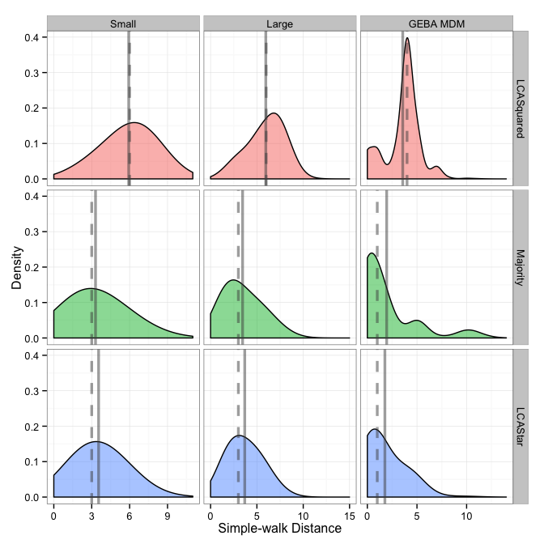

```r
# plotting parameters
my_line_col = "#4C4C4C"
line_size = 1.2
alpha_val = 0.5

dat <- all_df.m %>% subset(Sample %in% c("Small", "Large", "GEBA MDM"))
g2 <- ggplot(subset(dat, variable == "Walk"), aes(x=value, fill=Method))
# g2 <- g2 + geom_histogram(binwidth=2, alpha=0.8)
g2 <- g2 + geom_density(adjust=5, alpha=alpha_val)
g2 <- g2 + facet_grid(Method ~ Sample, scales = "free_x")
g2 <- g2 + theme(legend.position="none")
g2 <- g2 + geom_vline(aes(xintercept=mean), colour=my_line_col, size=line_size, alpha=alpha_val, subset(walk_means, Sample %in% c("Small", "Large", "GEBA MDM")))
g2 <- g2 + geom_vline(aes(xintercept=median), colour=my_line_col, linetype="dashed", size=line_size, alpha=alpha_val, subset(walk_means, Sample %in% c("Small", "Large", "GEBA MDM")))
g2 <- g2 + xlab("Simple-walk Distance")
g2 <- g2 + ylab("Density")
g2
```

```r
pdf(file = "pdfs/fig2.pdf", width = 7, height=7)
g2
dev.off()
```

**Figure 2:** Distribution of simple-walk distances of taxonomic predictions to contig origin: LCASquared, Majority, LCA*. Kernel densities for error distances from each of the three prediction methods on the two simluated and GEBA datasets.

Notes:

- In all cases, LCASquared perfomed on-aggregate more poorly than the voting-based methods, Majority and LCAStar.
- Means and Medians of predicted distances for LCASqared were consistently larger
- LCA* and Majority performed simmialrly in terms of distance from the target taxon, in fact in many cases they are one and the same when no entropy-based transformations need to occur
- Majority method has a slightly longer tail in the GEBA sample
- Medians are identical in all samples, better measure in slightly skewed distribution
- Simple-walk distance is a crude measure of taxonomic distance

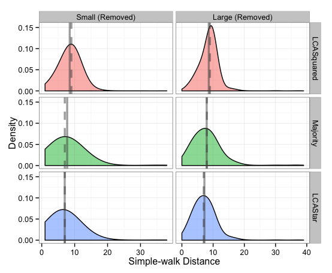

```r
dat <- all_df.m %>% subset(Sample %in% c("Small (Removed)", "Large (Removed)"))
g2a <- ggplot(subset(dat, variable == "Walk"), aes(x=value, fill=Method))
# g2a <- g2a + geom_histogram(binwidth=2, alpha=0.8)
g2a <- g2a + geom_density(adjust=5, alpha=alpha_val)
g2a <- g2a + facet_grid(Method ~ Sample, scales = "free_x")
g2a <- g2a + theme(legend.position="none")
g2a <- g2a + geom_vline(aes(xintercept=mean), colour=my_line_col, size=line_size, alpha=alpha_val, subset(walk_means, Sample %in% c("Small (Removed)", "Large (Removed)")))
g2a <- g2a + geom_vline(aes(xintercept=median), colour=my_line_col, linetype="dashed", size=line_size, alpha=alpha_val, subset(walk_means, Sample %in% c("Small (Removed)", "Large (Removed)")))
g2a <- g2a + xlab("Simple-walk Distance")
g2a <- g2a + ylab("Density")
g2a
```

```r
pdf(file = "pdfs/fig2a.pdf", width = 4.746032, height=5.779527)
g2a
dev.off()
```

Notes:

With RefSeq targets removed there is signifiant overlap and variance increase.

- Calculate means, medians

```r
means <- select(all_df.m, Method, Sample, variable, value) %>%
  group_by(Method, Sample, variable) %>%
  filter(variable== "WTD") %>%
  summarize(mean=mean(value, na.rm = T),
            percent_25 = quantile(value, probs = 0.25, na.rm = T),
            median = quantile(value, probs=0.5, na.rm = T),
            percent_75 = quantile(value, probs = 0.75, na.rm = T))
```

- Same thing again, expect using the weighted taxonomic distance.

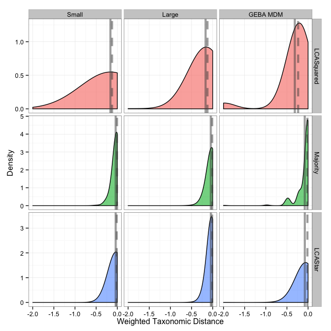

```r
dat <- all_df.m %>% subset(Sample %in% c("Small", "Large", "GEBA MDM"))
g3 <- ggplot(subset(dat, variable == "WTD"), aes(x=value, fill=Method))
g3 <- g3 + geom_density(adjust=20, alpha=0.6)
g3 <- g3 + facet_grid(Method ~ Sample, scales = "free_y")
g3 <- g3 + theme(legend.position="none")
g3 <- g3 + geom_vline(aes(xintercept=mean), colour=my_line_col, size=1.5, alpha=0.5, subset(means, Sample %in% c("Small", "Large", "GEBA MDM")))
g3 <- g3 + geom_vline(aes(xintercept=median), colour=my_line_col, linetype="dashed", size=1.5, alpha=0.5, subset(means, Sample %in% c("Small", "Large", "GEBA MDM")))
g3 <- g3 + xlab("Weighted Taxonomic Distance")
g3 <- g3 + ylab("Density")
g3
```

```r
pdf(file = "pdfs/fig3.pdf", width = 7, height=7)
g3
dev.off()
```

**Figure 3:** Distribution of WTD distances of taxonomic predictions to contig origin: LCASquared, Majority, LCA*. Kernel densities for error distances from each of the three prediction methods on the two simluated and GEBA datasets.

Notes:

Treating the whole thing as a regression problem we have the following RMSE values

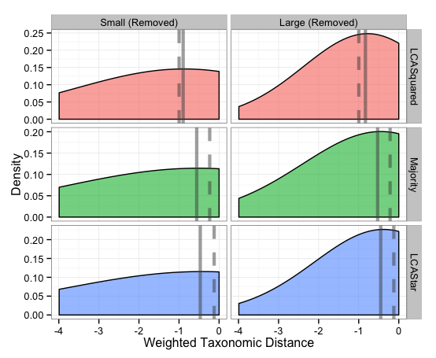

```r
dat <- all_df.m %>% subset(Sample %in% c("Small (Removed)", "Large (Removed)"))
g3a <- ggplot(subset(dat, variable == "WTD"), aes(x=value, fill=Method))
g3a <- g3a + geom_density(adjust=20, alpha=0.6)
g3a <- g3a + facet_grid(Method ~ Sample, scales = "free_y")
g3a <- g3a + theme(legend.position="none")
g3a <- g3a + geom_vline(aes(xintercept=mean), colour=my_line_col, size=1.5, alpha=0.5, subset(means, Sample %in% c("Small (Removed)", "Large (Removed)")))
g3a <- g3a + geom_vline(aes(xintercept=median), colour=my_line_col, linetype="dashed", size=1.5, alpha=0.5, subset(means, Sample %in% c("Small (Removed)", "Large (Removed)")))
g3a <- g3a + xlab("Weighted Taxonomic Distance")
g3a <- g3a + ylab("Density")
g3a
```

```r
pdf(file = "pdfs/fig3a.pdf", width = 4.746032, height=5.779527)
g3a
dev.off()
```

```r
# function for RMSE
rmse <- function(x) {
  sqrt(mean(x^2, na.rm = T))
}

ci <- function(x, sig=0.05) {

  x <- x[!is.na(x)] # remove NA
  x <- x^2 # squre
  N <- length(x)
  x_sd <- sd(x, na.rm=TRUE)

  x_se <- x_sd / sqrt(N)
  x_se <- sqrt(x_se)
  ciMult <- qt((1-sig)/2 + .5, N-1)
  x_ci <- x_se * ciMult
  x_ci
}

# function to compute standard errors
summarySE <- function(data=NULL, measurevar, groupvars=NULL, na.rm=FALSE,
                      conf.interval=.95, .drop=TRUE) {
    require(plyr)

    # New version of length which can handle NA's: if na.rm==T, don't count them
    length2 <- function (x, na.rm=FALSE) {
        if (na.rm) sum(!is.na(x))
        else       length(x)
    }

    # This does the summary. For each group's data frame, return a vector with
    # N, mean, and sd
    datac <- ddply(data, groupvars, .drop=.drop,
      .fun = function(xx, col) {
        c(N    = length2(xx[[col]], na.rm=na.rm),
          mean = mean   (xx[[col]], na.rm=na.rm),
          sd   = sd     (xx[[col]], na.rm=na.rm)
        )
      },
      measurevar
    )

    # Rename the "mean" column
    datac <- rename(datac, c("mean" = measurevar))

    datac$se <- datac$sd / sqrt(datac$N)  # Calculate standard error of the mean

    # Confidence interval multiplier for standard error
    # Calculate t-statistic for confidence interval:
    # e.g., if conf.interval is .95, use .975 (above/below), and use df=N-1
    ciMult <- qt(conf.interval/2 + .5, datac$N-1)
    datac$ci <- datac$se * ciMult

    return(datac)
}

res <- select(all_df.m, Method, Sample, variable, value) %>%
       filter(variable %in% c("Walk", "WTD")) %>%
       group_by(Method, Sample, variable) %>%
       summarize(n_obs = n(), RMSE = rmse(value), sd=sd(value, na.rm=TRUE),ci=ci(value, sig=0.05), na.rm=TRUE)
```

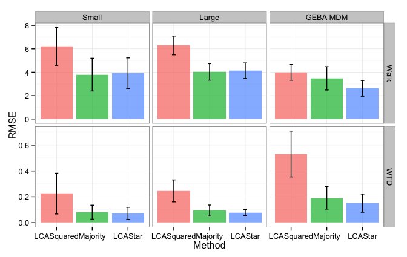

```r
dat <- res %>% subset(Sample %in% c("Small", "Large", "GEBA MDM"))
g4 <- ggplot(dat, aes(y=RMSE, x =Method, fill=Method))
g4 <- g4 + geom_bar(stat="identity", alpha=0.7)
g4 <- g4 + facet_grid(variable~Sample, scales="free_y")
g4 <- g4 + theme(legend.position="none")
g4 <- g4 + geom_errorbar(aes(ymin=RMSE-ci, ymax=RMSE+ci), width=.1)
g4
```

```r
pdf(file = "pdfs/fig4.pdf", width = 7, height=4.43)
g4
dev.off()
```

**Figure 4:** RMSE Values for our prediction errors in the simple Walk and WTD.

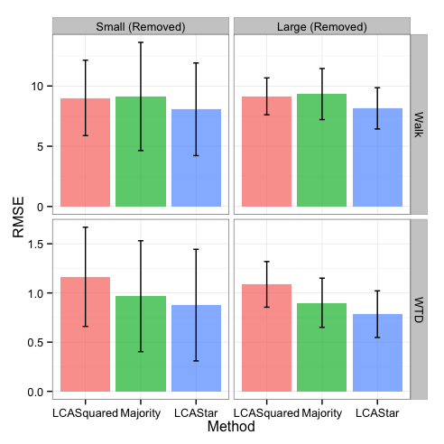

```r
dat <- res %>% subset(Sample %in% c("Small (Removed)", "Large (Removed)"))
g4a <- ggplot(dat, aes(y=RMSE, x =Method, fill=Method))
g4a <- g4a + geom_bar(stat="identity", alpha=0.7)
g4a <- g4a + facet_grid(variable~Sample, scales="free_y")
g4a <- g4a + theme(legend.position="none")
g4a <- g4a + geom_errorbar(aes(ymin=RMSE-ci, ymax=RMSE+ci), width=.1)
g4a
```

```r
pdf(file = "pdfs/fig4a.pdf", width = 5.134921, height=5.125984)
g4a
dev.off()
```

[output not shown]

**Figure 4a:** RMSE Values for our prediction errors in the simple Walk and WTD (targets removed).

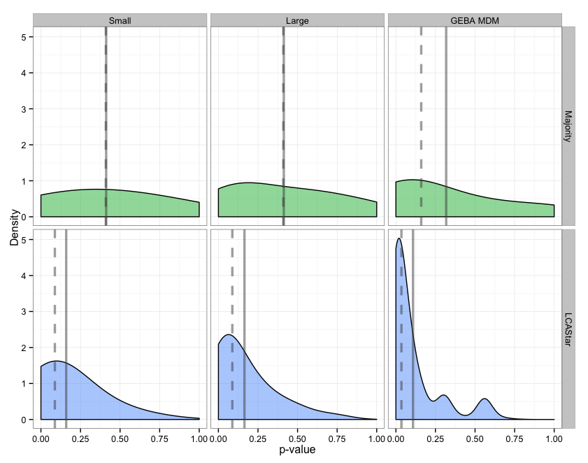

```r
means <- select(all_df.m, Method, Sample, variable, value) %>%
  filter(variable== "p-value" & Method %in% c("Majority", "LCAStar")) %>%
  group_by(Method, Sample, variable) %>%
  summarize(mean=mean(value, na.rm = T),
            percent_25 = quantile(value, probs = 0.25, na.rm = T),
            median = quantile(value, probs=0.5, na.rm = T),
            percent_75 = quantile(value, probs = 0.75, na.rm = T))
dat_means <- means %>% subset(Sample %in% c("Small", "Large", "GEBA MDM"))
dat <- all_df.m %>% subset(Sample %in% c("Small", "Large", "GEBA MDM"))
g5 <- ggplot(subset(dat, variable == "p-value" & Method %in% c("Majority", "LCAStar")), aes(x=value, fill=Method))
g5 <- g5 + geom_density(adjust=5, alpha=alpha_val)
g5 <- g5 + facet_grid(Method~Sample)
g5 <- g5 + xlab("p-value")
g5 <- g5 + ylab("Density")
g5 <- g5 + geom_vline(aes(xintercept=median), colour=my_line_col, linetype="dashed", size=line_size, alpha=alpha_val, dat_means)
g5 <- g5 + geom_vline(aes(xintercept=mean), colour=my_line_col, size=line_size, alpha=alpha_val, dat_means)
g5 <- g5 + scale_fill_manual(values=c("#1BB840", "#649EFC"))
g5 <- g5 + theme(legend.position="none")
g5
```

```r
pdf(file = "pdfs/fig5.pdf", width = 8.77, height=6.897)
g5
dev.off()
```

**Figure 5:** p-value distribution of the Majority and LCA* predictions.

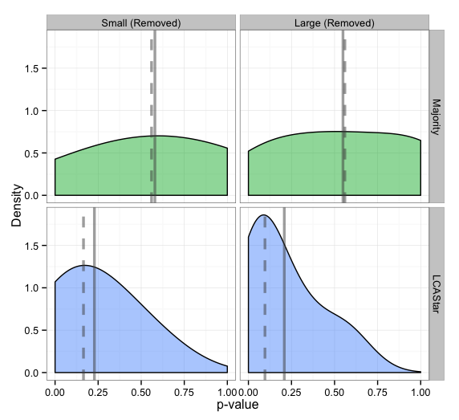

```r
dat_means <- means %>% subset(Sample %in% c("Small (Removed)", "Large (Removed)"))
dat <- all_df.m %>% subset(Sample %in% c("Small (Removed)", "Large (Removed)"))
g5a <- ggplot(subset(dat, variable == "p-value" & Method %in% c("Majority", "LCAStar")), aes(x=value, fill=Method))
g5a <- g5a + geom_density(adjust=5, alpha=alpha_val)
g5a <- g5a + facet_grid(Method~Sample)
g5a <- g5a + xlab("p-value")
g5a <- g5a + ylab("Density")
g5a <- g5a + geom_vline(aes(xintercept=median), colour=my_line_col, linetype="dashed", size=line_size, alpha=alpha_val, dat_means)
g5a <- g5a + geom_vline(aes(xintercept=mean), colour=my_line_col, size=line_size, alpha=alpha_val, dat_means)
g5a <- g5a + scale_fill_manual(values=c("#1BB840", "#649EFC"))
g5a <- g5a + theme(legend.position="none")
g5a
```

```r
pdf(file = "pdfs/fig5a.pdf", width = 5.968254, height=5.456693)
g5a
dev.off()
```

**Figure 5a:** p-value distribution of the Majority and LCA* (targets removed).

Please direct any questions or comments to Dr. Steven J. Hallam (shallam@mail.ubc.ca), Department of Microbiology & Immunology, University of British Columbia.

References

[1]K. M. Konwar, N. W. Hanson, A. P. Pagé, and S. J. Hallam, “MetaPathways: a modular pipeline for constructing pathway/genome databases from environmental sequence information.” *BMC Bioinformatics*, vol. 14, no. 1, p. 202, 2013.

[2]N. W. Hanson, K. M. Konwar, S.-J. Wu, and S. J. Hallam, “MetaPathways v2.0: A master-worker model for environmental Pathway/Genome Database construction on grids and clouds,” *Computational Intelligence in Bioinformatics and Computational Biology, 2014 IEEE Conference on*, pp. 1–7, May 2014.

[3]K. D. Pruitt, T. Tatusova, and D. R. Maglott, “NCBI reference sequences (RefSeq): a curated non-redundant sequence database of genomes, transcripts and proteins.” *Nucleic Acids Research*, vol. 35, no. Database issue, pp. D61–5, Jan. 2007.

[4]S. Federhen, “The NCBI Taxonomy database.” *Nucleic Acids Research*, vol. 40, no. Database issue, pp. D136–43, Jan. 2012.

[5]N. W. Hanson, K. M. Konwar, A. K. Hawley, T. Altman, P. D. Karp, and S. J. Hallam, “Metabolic pathways for the whole community.” *BMC Genomics*, vol. 15, p. 619, 2014.

[6]K. M. Konwar, N. W. Hanson, M. P. Bhatia, D. Kim, S.-J. Wu, A. P. Hahn, C. Morgan-Lang, H. K. Cheung, and S. J. Hallam, “MetaPathways v2.5: Quantitative functional, taxonomic, and usability improvements.” *Bioinformatics*, pp. 1–3, Jan. 2015.

[7]C. Rinke, P. Schwientek, A. Sczyrba, N. N. Ivanova, I. J. Anderson, J.-F. Cheng, A. Darling, S. Malfatti, B. K. Swan, E. A. Gies, J. A. Dodsworth, B. P. Hedlund, G. Tsiamis, S. M. Sievert, W.-T. Liu, J. A. Eisen, S. J. Hallam, N. C. Kyrpides, R. Stepanauskas, E. M. Rubin, P. Hugenholtz, and T. Woyke, “Insights into the phylogeny and coding potential of microbial dark matter.” *Nature*, vol. 499, no. 7459, pp. 431–437, Jul. 2013.

[8]S. M. Kiełbasa, R. Wan, K. Sato, P. Horton, and M. C. Frith, “Adaptive seeds tame genomic sequence comparison.” *Genome Res*, vol. 21, no. 3, pp. 487–493, Mar. 2011.